# Cap 4_Relationships between words_n-grams and correlations

Macarena Quiroga

2/13/2022

> Este texto es una traducción adaptada por mí del libro [Text Mining with R](https://www.tidytextmining.com/preface.html) de Julia Silge y David Robinson.

En este capítulo vamos a ver distintos métodos para calcular y visualizar las relaciones *entre* las palabras del dataset. El token que se usa es **ngrams**, que consiste en pares de palabras adyacentes. Agregamos dos paquetes nuevos: `ggraph`, que extiende `ggplot2`, y `widyr`, que calcula correlaciones apareadas y distancias dentro de un df.

## 4.1 Tokenizando por n-gram

La función `unnest_tokens()` también nos sirve para tokenizar con “n-gram” como unidad, lo cual nos permite ver qué tan seguido la palabra X es seguida por la palabra Y. Especificamos `token = "ngrams"` y `n = 2`, para aclarar que buscamos pares de dos palabras consecutivas:

```r
library(dplyr)
library(tidytext)
library(janeaustenr)

austen_bigrams <- austen_books() %>%
  unnest_tokens(bigram, text, token = "ngrams", n = 2)
```

## 4.2 Contar y filtrar n-grams

Ahora podemos contar cuáles son los bigrams más frecuentes:

```r
austen_bigrams %>%
  count(bigram, sort = TRUE)
```

```
## # A tibble: 193,210 × 2
##    bigram      n
##    <chr>   <int>
##  1 <NA>    12242
##  2 of the   2853
##  3 to be    2670
##  4 in the   2221
##  5 it was   1691
##  6 i am     1485
##  7 she had  1405
##  8 of her   1363
##  9 to the   1315
## 10 she was  1309
## # … with 193,200 more rows
```

Lo que vemos es que los bigrams más frecuentes son pares de palabras que no nos interesan, artículos y preposiciones. Para mejorar esto, podemos usar la función `separate()`, que divide una columna en varias; vamos a dividir entre “palabra1” y “palabra2”, para remover los casos donde alguna de ellas es una stop-word.

```r
library(tidyr)
bigrams_separated <- austen_bigrams %>%
  separate(bigram, c("word1", "word2"), sep = " ")

bigrams_filtered <- bigrams_separated %>%
  filter(!word1 %in% stop_words$word) %>% # quedarse con las palabras que no se encuentran en el df de stop_words, en la columna específica de las palabras
  filter(!word2 %in% stop_words$word)

# contamos de nuevo
bigram_counts <- bigrams_filtered %>%
  count(word1, word2, sort = TRUE) # acá cuenta combinaciones de palabras
```

Si queremos volver a unificar las dos palabras en un bigram, podemos usar `unite()`:

```r
bigrams_united <- bigrams_filtered %>%
  unite(bigram, word1, word2, sep = " ")
```

Podemos trabajar con trigrams:

```r
austen_trigrams <- austen_books() %>%
  unnest_tokens(trigram, text, token = "ngrams", n = 3) %>%
  separate(trigram, c("word1", "word2", "word3"), sep = " ") %>%
  filter(!word1 %in% stop_words$word,
         !word2 %in% stop_words$word,
         !word3 %in% stop_words$word) %>%
  count(word1, word2, word3, sort = TRUE)
```

## 4.2 Analizando bígramos

Los bígramos nos sirven para hacer análisis exploratorios. Si quisiéramos saber cuáles son las calles más frecuentes, podemos buscar aquel bígramo cuya segunda palabra sea “street”:

```r
bigrams_filtered %>%
  filter(word2 == "street") %>%
  count(book, word1, sort = TRUE)
```

```
## # A tibble: 33 × 3
##    book                word1           n
##    <fct>               <chr>       <int>
##  1 Sense & Sensibility harley         16
##  2 Sense & Sensibility berkeley       15
##  3 Northanger Abbey    milsom         10
##  4 Northanger Abbey    pulteney       10
##  5 Mansfield Park      wimpole         9
##  6 Pride & Prejudice   gracechurch     8
##  7 Persuasion          milsom          5
##  8 Sense & Sensibility bond            4
##  9 Sense & Sensibility conduit         4
## 10 Persuasion          rivers          4
## # … with 23 more rows
```

Los bígramos también pueden ser utilizados como unidades para análisis como los realizados en el capítulo 3, a partir del cálculo del tf_idf.

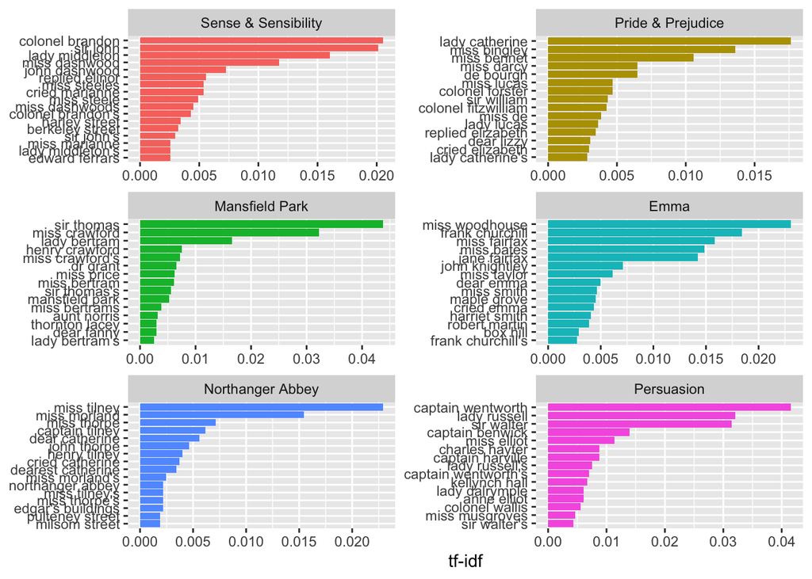

```r
bigram_tf_idf <- bigrams_united %>%
  count(book, bigram) %>%
  bind_tf_idf(bigram, book, n) %>%
  arrange(desc(tf_idf))

library(forcats)
library(ggplot2)

bigram_tf_idf %>%
  group_by(book) %>%
  slice_max(tf_idf, n = 15) %>%
  ungroup() %>%
  ggplot(aes(tf_idf, fct_reorder(bigram, tf_idf), fill = book)) +
  geom_col(show.legend = FALSE) +
  facet_wrap(~book, ncol = 2, scales = "free") +
  labs(x = "tf-idf", y = NULL)
```

El gráfico muestra que los bígramos más usados en cada libro corresponden a los personas más importantes, lo cual indica que el cálculo estuvo bien realizado. Usar bígramos tiene la ventaja de dar más contexto a las palabras más frecuentes, pero tiene la desventaja de que el análisis está más disperso, porque el bígramo más frecuente tiene una frecuencia mucho menor que cualquiera de las dos palabras por separado. Por lo tanto, es un análisis que solo tiene sentido en datasets largos.

En el capítulo 2 hicimos un análisis de sentimiento solamente analizando palabras según su significado positivo o negativo; sin embargo, el contexto de una palabra puede ser tanto o más importante que su presencia. Por ejemplo, las palabras “gusta” y “contento” cuentan como positivas aunque la frase sea “No me gusta y no estoy contento”.

Tener los datos organizados en bígramos nos permite ver, por ejemplo, cuántas palabras están emparejadas con la palabra “not”:

```r
bigrams_separated %>%
  filter(word1 == "not") %>%
  count(word1, word2, sort = TRUE)
```

```
## # A tibble: 1,178 × 3
##    word1 word2     n
##    <chr> <chr> <int>
##  1 not   be      580
##  2 not   to      335
##  3 not   have    307
##  4 not   know    237
##  5 not   a       184
##  6 not   think   162
##  7 not   been    151
##  8 not   the     135
##  9 not   at      126
## 10 not   in      110
## # … with 1,168 more rows
```

Podemos usar esta información para excluir o bien para invertir los puntajes. Vamos a usar el diccionario AFINN, que da valores numéricos para el sentimiento de cada palabra, ya sean números positivos o negativos. Con eso, podemos examinar las palabras más frecuentes que estuvieron precedidas por “not” y que estaban asociadas con un sentimiento.

```r
AFINN <- get_sentiments("afinn")
not_words <- bigrams_separated %>%
  filter(word1 == "not") %>%
  inner_join(AFINN, by = c(word2 = "word")) %>%
  count(word2, value, sort = TRUE)
```

A partir de esto podemos calcular cuántas de estas palabras aportaron a la dirección “opuesta”. Para eso, multiplicamos su valor por la cantidad de veces que aparecen.

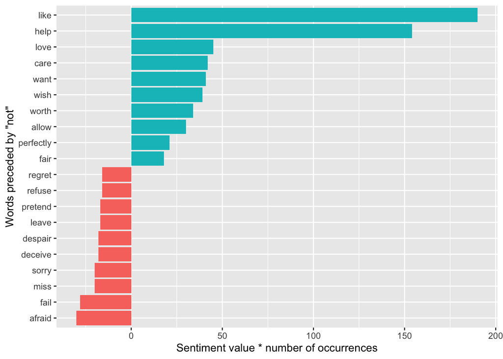

```r
not_words %>%
  mutate(contribution = n*value) %>%
  arrange(desc(abs(contribution))) %>% # en valores absolutos porque hay negativos
  head(20) %>%  # solo los primeros 20
  mutate(word2 = reorder(word2, contribution)) %>%
  ggplot(aes(contribution, word2, fill = contribution > 0))+
  geom_col(show.legend = FALSE)+
  labs(x = "Sentiment value * number of occurrences",
       y = "Words preceded by \"not\"")
```

El gráfico nos muestra que los bígramos “not like” y “not help” generaron que el texto pareciera más positivo de lo que era, y frases como “not afraid” y “not fail” lo hicieron parecer más negativo de lo que era.

```r
negation_words <- c("not", "no", "never", "without")
negated_words <- bigrams_separated %>%
  filter(word1 %in% negation_words) %>%
  inner_join(AFINN, by = c(word2 = "word")) %>%
  count(word1, word2, value, sort = TRUE)
```

### 4.1.4 Visualizar una red de bígramos con ggraph

Podemos visualizar la relación entre todas las palabras a partir de una red de puntos conectados. Una red se puede crear a partir de un objeto tidy porque tiene tres variables: el nodo **desde** el cual sale una arista, el nodo **hacia** el cual va la arista, y el **peso**, que es el valor numérico asociado con cada arista.

El paquete `igraph` tiene muchas funciones poderosas para manipular y analizar redes. Una forma de crear un objeto igraph a partir de tidy data es la función `graph_from_data_frame()`, que toma un data frame de aristas con las columnas *from*, *to* y los atributos de la arista (en este caso, *n*).

```r
library(igraph)
bigram_graph <- bigram_counts %>%
  filter(n > 20) %>% # para filtrar los bígramos más comunes
  graph_from_data_frame()
```

Para visualizar esta red, podemos usar el paquete `ggraph`, que usa la misma gramática de gráficos que `ggplot2`. Podemos convertir un objeto igraph en un objeto ggraph con la función `ggraph`; luego, agregamos capas de la misma forma que lo haríamos con `ggplot2`. Por ejemplo, en este caso necesitaríamos agregar tres capas: nodos, aristas y texto.

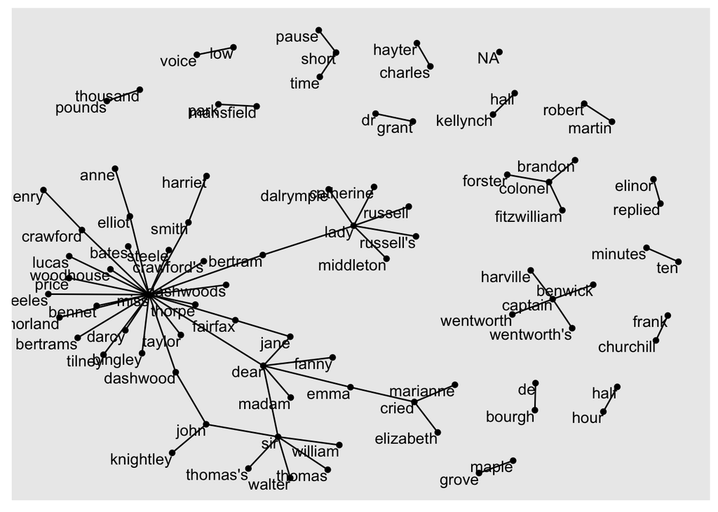

```r
library(ggraph)
set.seed(2017)
ggraph(bigram_graph, layout = "fr")+
  geom_edge_link()+
  geom_node_point()+
  geom_node_text(aes(label = name), vjust = 1, hjust = 1)
```

Podemos mejorar la estética del gráfico agregando `edge_alpha` a la capa del link para volverlos transparentes según su grado de rareza. Agregamos direccionalidad con una flecha con `grid::arrow()`, incluyendo la opción `end_cap` que le indica a la flecha que termine antes de tocar el nodo. Modificamos las opciones de la capa del nodo para hacerlos más atractivos (más grandes, de color azul). Finalmente, agregamos un theme que es útil para este tipo de redes, `theme_void()`.

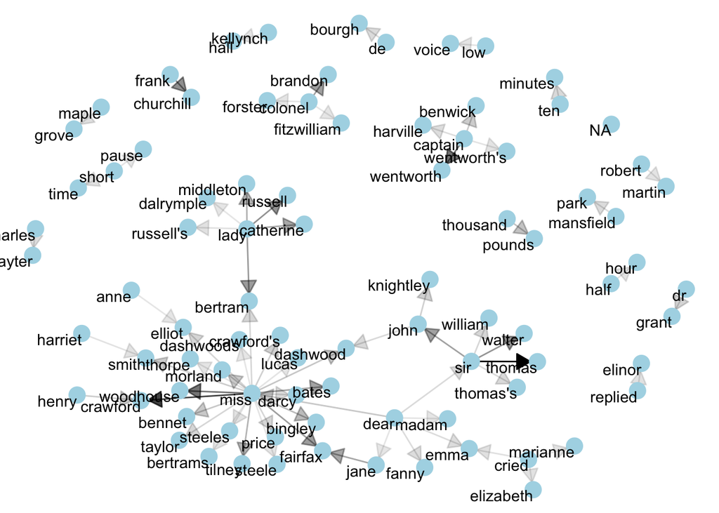

```r
set.seed(2020)
a <- grid::arrow(type = "closed", length = unit(.15, "inches"))
ggraph(bigram_graph, layout = "fr")+
  geom_edge_link(aes(edge_alpha = n), show.legend = FALSE,
                 arrow = a, end_cap = circle(.07, 'inches'))+
  geom_node_point(color = "lightblue", size = 5)+
  geom_node_text(aes(label = name), vjust = 1, hjust = 1)+
  theme_void()
```

Esta es una visualización del tipo **Markov chain**, donde cada elección de palabra depende solo de la palabra previa. En este caso, un generador al azar que use este modelo podría devolver “dear”, después “sir” y después “william/walter/thomas/thomas’s”, agregando a cada palabra la palabra más común que le sigue. Para poder volver interpretable la visualización, elegimos mostrar solamente las conexiones más frecuentes entre palabras, pero uno podría imaginar un gráfico gigantesco que represente todas las conexiones que se dan en el texto.

### 4.1.5 Visualizar bígramos en otros textos

Podemos utilizar todo el trabajo realizado para limpiar y visualizar los bígramos en el dataset de texto para convertirlo en una función que nos permita realizarlo en otro dataset.

```r
library(dplyr)
library(tidyr)
library(tidytext)
library(ggplot2)
library(igraph)
library(ggraph)

count_bigrams <- function(dataset){
  dataset %>%
    unnest_tokens(bigram, text, token = "ngrams", n = 2) %>%
    separate(bigram, c("word1", "word2"), sep = " ") %>%
    filter(!word1 %in% stop_words$word,
           !word2 %in% stop_words$word) %>%
    count(word1, word2, sort = TRUE)
}

visualize_bigrams <- function(bigrams){
  set.seed(2016)
  a <- grid::arrow(type = "closed", length = unit(.15, "inches"))

  bigrams %>%
    graph_from_data_frame() %>%
    ggraph(layout = "fr")+
    geom_edge_link(aes(edge_alpha = n), show.legend = FALSE, arrow = a)+
    geom_node_point(color = "lightblue", size = 5)+
    geom_node_text(aes(label = name), vjust = 1, hjust = 1)+
    theme_void()
}
```

Esto nos permite visualizar bígramos en otras obras, como en la versión King James de la Biblia:

```r
library(gutenbergr)
kjv <- gutenbergr::gutenberg_download(10)
```

```
## Determining mirror for Project Gutenberg from http://www.gutenberg.org/robot/harvest
```

```
## Using mirror http://aleph.gutenberg.org
```

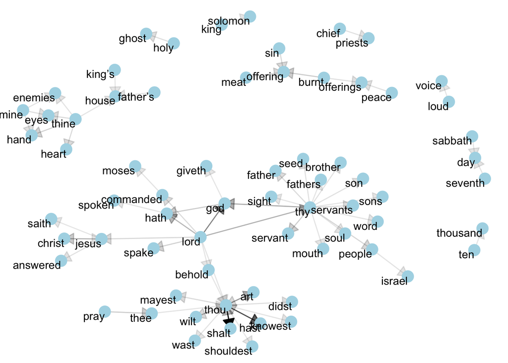

```r
library(stringr)
kjv_bigrams <- kjv %>%
  count_bigrams()

kjv_bigrams %>%
  filter(n > 40,
         !str_detect(word1, "\\d"),
         !str_detect(word2, "\\d")) %>%
  visualize_bigrams()
```

## 4.2 Contar y correlacionar pares de palabras con el paquete `widyr`

Tokenizar a partir de n-grams es una buena forma de explorar pares de palabras adyacentes. Sin embargo, también podemos estar interesados en palabras que tienden a co-ocurrir dentro de determinados documentos y capítulos, aunque no aparezcan una al lado de la otra.

Tidy data es una estructura útil para comparar entre variables o agrupaciones de filas, pero puede ser difícil comparar entre filas: por ejemplo, para contar la cantidad de veces que dos palabras aparece dentro del mismo capítulo, o para ver qué tan correlacionadas están. La mayoría de las operaciones para encontrar conteos emparejados o correlaciones necesitan convertir los datos en una matriz ancha [wide] primero.

Vamos a examinar algunas formas en las que se pueden convertir textos tidy en matrices anchas en el capítulo 5, pero en este caso no es necesario. El paquete `widyr` permite realizar operaciones como computar conteos y correlaciones de forma sencilla, simplificando el patrón de “ensanchar los datos, realizar la operación, volver a limpiar los datos”. Nos enfocaremos en una serie de funciones que realizan comparaciones emparejadas entre grupos de observaciones (por ejemplo, entre documentos o entre secciones de un mismo texto).

### 4.2.1 Contar y correlacionar entre secciones

Tomemos el libro “Pride and prejudice” dividido en secciones de 10 líneas, como hicimos para el análisis de sentimientos en el Capítulo 2. Podemos estar interesados en qué palabras tienden a aparecer dentro de la misma sección.

```r
austen_section_books <- austen_books() %>%
  filter(book == "Pride & Prejudice") %>%
  mutate(section = row_number() %/% 10) %>% # %/% significa división de integrales (división completa sin excedentes), por lo que entiendo excluye las primeras 10 líneas
  filter(section > 0) %>%
  unnest_tokens(word, text) %>%
  filter(!word %in% stop_words$word)
```

Una función útil del paquete `widyr` es `pairwise_count()`. El prefijo `pairwise_` indica que el resultado es una fila por cada par de palabras en la variable `word`. Esto nos permite contar pares comunes de palabras co-apareciendo dentro de la misma sección.

```r
library(widyr)
```

```r
# conteo de palabras que co-aparecen dentro de las secciones
word_pairs <- austen_section_books %>%
  pairwise_count(word, section, sort = TRUE)
```

Por lo tanto, mientras que el input tenía una fila para una sección del documento y una palabra, el output tiene una fila por cada par de palabras. Esto también es un formato tidy, pero con una estructura distinta que nos permitirá responder nuevas preguntas.

Por ejemplo, podemos ver que los pares de palabras más comunes dentro de una sección son “Elizabeth” y “Darcy” (los dos protagonistas). Podemos fácilmente encontrar las palabras que co-ocurren más frecuentemente con Darcy:

```r
word_pairs %>%
  filter(item1 == "darcy")
```

```
## # A tibble: 2,930 × 3
##    item1 item2         n
##    <chr> <chr>     <dbl>
##  1 darcy elizabeth   144
##  2 darcy miss         92
##  3 darcy bingley      86
##  4 darcy jane         46
##  5 darcy bennet       45
##  6 darcy sister       45
##  7 darcy time         41
##  8 darcy lady         38
##  9 darcy friend       37
## 10 darcy wickham      37
## # … with 2,920 more rows
```

### 4.2.2 Correlaciones apareadas

Las coocurrencias de las palabras como “Elizabeth” y “Darcy” no son, de todos modos, muy informativas, porque son las palabras más frecuentes incluso de forma individual. En lugar de eso, podemos examinar las **correlaciones** entre las palabras, lo que indica qué tan frecuentemente aparecen juntas respecto a qué tan frecuentemente aparecen separadas.

En particular, aquí vamos a enfocarnos en el [coeficiente phi](https://en.wikipedia.org/wiki/Phi_coefficient) una medida comúnmente usada en correlaciones binarias. El objetivo del coeficiente phi es mostrar qué tan probable es que **cualquiera de las dos** palabras X e Y aparezcan, o que **ninguna** lo haga, frente a que aparezca una sin la otra. Es equivalente a la **correlación de Pearson**.

La función `pairwise_cor()` de `widyr` nos permite calcular el coeficiente phi entre palabras basado en su frecuencia de aparición en la misma sección. Su sintaxis es parecida a `pairwise_count()`.

```r
# primero filtramos las palabras relativamente frecuentes
word_cors <- austen_section_books %>%
  group_by(word) %>%
  filter(n() >= 20) %>%
  pairwise_cor(word, section, sort = TRUE)

word_cors
```

```
## # A tibble: 154,842 × 3
##    item1     item2     correlation
##    <chr>     <chr>           <dbl>
##  1 bourgh    de              0.951
##  2 de        bourgh          0.951
##  3 pounds    thousand        0.701
##  4 thousand  pounds          0.701
##  5 william   sir             0.664
##  6 sir       william         0.664
##  7 catherine lady            0.663
##  8 lady      catherine       0.663
##  9 forster   colonel         0.622
## 10 colonel   forster         0.622
## # … with 154,832 more rows
```

Esta forma de organizar la información nos permite hacer búsquedas específicas, por ejemplo las palabras más correlacionadas con la palabra “pound”.

```r
word_cors %>%
  filter(item1 == "pounds")
```

```
## # A tibble: 393 × 3
##    item1  item2     correlation
##    <chr>  <chr>           <dbl>
##  1 pounds thousand       0.701
##  2 pounds ten            0.231
##  3 pounds fortune        0.164
##  4 pounds settled        0.149
##  5 pounds wickham's      0.142
##  6 pounds children       0.129
##  7 pounds mother's       0.119
##  8 pounds believed       0.0932
##  9 pounds estate         0.0890
## 10 pounds ready          0.0860
## # … with 383 more rows
```

Podemos seleccionar palabras interesantes y buscar con qué palabras suelen asociarse:

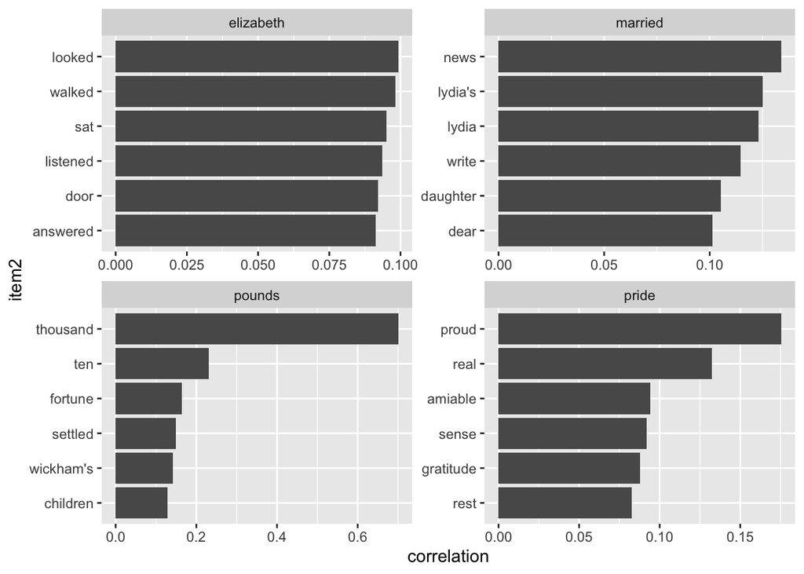

```r
word_cors %>%
  filter(item1 %in% c("elizabeth", "pounds", "married", "pride")) %>%
  group_by(item1) %>%
  slice_max(correlation, n = 6) %>%
  ungroup() %>%
  mutate(item2 = reorder(item2, correlation)) %>%
  ggplot(aes(item2, correlation))+
  geom_bar(stat = "identity")+
  facet_wrap(~item1, scales = "free")+
  coord_flip()
```

Y podemos usar `ggraph` para visualizar las correlaciones y los grupos de palabras que encontramos:

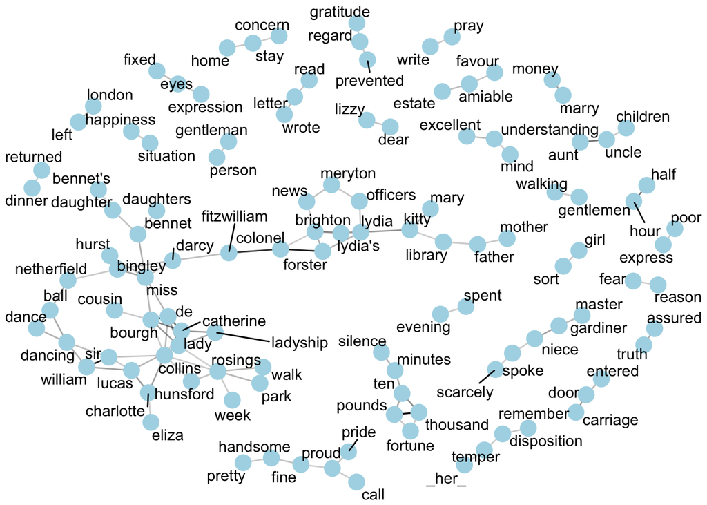

```r
set.seed(2016)
word_cors %>%
  filter(correlation > .15) %>%
  graph_from_data_frame() %>%
  ggraph(layout = "fr")+
  geom_edge_link(aes(edge_alpha = correlation), show.legend = FALSE)+
  geom_node_point(color = "lightblue", size = 5)+
  geom_node_text(aes(label = name), repel = TRUE)+
  theme_void()
```

En este gráfico, a diferencia de los análisis de bígramos, las relaciones son simétricas (no hay flechas). Vemos también que, si bien siguen siendo comunes los emparejamientos de nombres y títulos que dominaban los bígramos, aquí aparecen también otros emparejamientos como “walk” y “park”.